# R Basics Solutions

Go back to the main page  
Go back to the R overview page

This file can be downloaded here

## R Basics

1. Create a vector with elements 1, 2, 3. Assign to variable `vec1`.

```r
vec1 <- c(1, 2, 3)
vec1
```

```
## [1] 1 2 3
```

2. Calculate the length of the vector.

```r
length(vec1)
```

```
## [1] 3
```

3. What class type is the vector?

```r
class(vec1)
```

```
## [1] "numeric"
```

4. Calculate the mean.

```r
mean(vec1)
```

```
## [1] 2
```

5. Calculate the median.

```r
median(vec1)
```

```
## [1] 2
```

6. Calculate the standard deviation.

```r
sd(vec1)
```

```
## [1] 1
```

7. Create a vector with elements 1 to 10. Use the `:` notation. Assign to variable `vec2`.

```r
vec2 <- 1:10
vec2
```

```
##  [1]  1  2  3  4  5  6  7  8  9 10
```

8. Create a sequence of 1 to 10. Only odd numbers. Assign to variable `vec3`.

```r
vec3 <- seq(1, 10, 2)
vec3
```

```
## [1] 1 3 5 7 9
```

9. Create a vector from vector `a` repeated 10 times. Assign to `vec4`

```r
vec4 <- rep("a", 10)
vec4
```

```
##  [1] "a" "a" "a" "a" "a" "a" "a" "a" "a" "a"
```

10. Use the `paste` function to concatenate strings `hello` and `world`.

```r
paste("Hello", "world")
```

```
## [1] "Hello world"
```

11. Use the `paste0` function to concatenate strings `hello` and `world`.

```r
paste0("Hello", "world")
```

```
## [1] "Helloworld"
```

12. Print all letters of the alphabet.

```r
letters
```

```
##  [1] "a" "b" "c" "d" "e" "f" "g" "h" "i" "j" "k" "l" "m" "n" "o" "p" "q" "r" "s"
## [20] "t" "u" "v" "w" "x" "y" "z"
```

13. Print all letters of the alphabet in capitals.

```r
LETTERS
```

```
##  [1] "A" "B" "C" "D" "E" "F" "G" "H" "I" "J" "K" "L" "M" "N" "O" "P" "Q" "R" "S"
## [20] "T" "U" "V" "W" "X" "Y" "Z"
```

14. Assign all letters of the alphabet to `vec5`.

```r
vec5 <- letters
vec5
```

```
##  [1] "a" "b" "c" "d" "e" "f" "g" "h" "i" "j" "k" "l" "m" "n" "o" "p" "q" "r" "s"
## [20] "t" "u" "v" "w" "x" "y" "z"
```

15. Use `toupper` function to convert letters to capitals.

```r
toupper(vec5)
```

```
##  [1] "A" "B" "C" "D" "E" "F" "G" "H" "I" "J" "K" "L" "M" "N" "O" "P" "Q" "R" "S"
## [20] "T" "U" "V" "W" "X" "Y" "Z"
```

16. Select first element of `vec5`.

```r
vec5[1]
```

```
## [1] "a"
```

17. Select all but the first element of `vec5`.

```r
vec5[-1]
```

```
##  [1] "b" "c" "d" "e" "f" "g" "h" "i" "j" "k" "l" "m" "n" "o" "p" "q" "r" "s" "t"
## [20] "u" "v" "w" "x" "y" "z"
```

18. Print last 6 elements of `vec5`.

```r
tail(vec5)
```

```
## [1] "u" "v" "w" "x" "y" "z"
```

19. Print last element of `vec5`.

```r
tail(vec5, 1)
```

```
## [1] "z"
```

20. Create a factor “G”, “V”, “O”, “V”, “G”. Add levels and order. Assign to `fac1`.

```r
fac1 <- factor(c("G", "V", "O", "V", "G"), levels = c("O", "V", "G"), order = T)
fac1
```

```
## [1] G V O V G
## Levels: O < V < G
```

21. Print all elements larger than “V” from `fac1`.

```r
fac1 > "V"
```

```
## [1]  TRUE FALSE FALSE FALSE  TRUE
```

22. Create vector 1, 2, 3. Assign to `vec6`. Add 1 to each element.

```r
vec6 <- c(1, 2, 3)
vec6 + 1
```

```
## [1] 2 3 4
```

23. Create vector one, 2, 3. Assign to `vec7`. What class is this vector?

```r
vec7 <- c("one", 2, 3)
class(vec7)
```

```
## [1] "character"
```

24. Create a data frame `df1` of two columns: 1, 2, 3 and 4, 5, 6.

```r
df1 <- data.frame(c(1, 2, 3), c(4, 5, 6))
df1
```

```
##   c.1..2..3. c.4..5..6.
## 1          1          4
## 2          2          5
## 3          3          6
```

25. Add column names “col1” and “col2”.

```r
names(df1) <- c("col1", "col2")
df1
```

```
##   col1 col2
## 1    1    4
## 2    2    5
## 3    3    6
```

26. Add column `col3` that consist of vector 7, 8, 9.

```r
df1$col3 <- c(7, 8, 9)
df1
```

```
##   col1 col2 col3
## 1    1    4    7
## 2    2    5    8
## 3    3    6    9
```

27. Select the second column by index.

```r
df1[2]
```

```
##   col2
## 1    4
## 2    5
## 3    6
```

28. Select the second column by name.

```r
df1$col2
```

```
## [1] 4 5 6
```

29. Select the first column by index in [, ] notation.

```r
df1[, 1]
```

```
## [1] 1 2 3
```

30. Select the third column by index in [, ] notation.

```r
df1[, 3]
```

```
## [1] 7 8 9
```

31. Create `df2` with columns `col4`, `col5` and `col6`. Assign to vectors c(10, 11, 12), c(13, 14, 15), c(16, 17, 18).

```r
df2 <- data.frame("col4" = c(10, 11, 12), "col5" = c(13, 14, 15), "col6" = c(16, 17, 18))
df2
```

```
##   col4 col5 col6
## 1   10   13   16
## 2   11   14   17
## 3   12   15   18
```

32. Sum the data frames `df1` and `df2`.

```r
df3 <- df1 + df2
df3
```

```
##   col1 col2 col3
## 1   11   17   23
## 2   13   19   25
## 3   15   21   27
```

33. Add 1 to all values of `col3`.

```r
df3[3] + 1
```

```
##   col3
## 1   24
## 2   26
## 3   28
```

34. Print `col3`.

```r
df3[3]
```

```
##   col3
## 1   23
## 2   25
## 3   27
```

35. Add 1 to all values of `col3` and save to df3.

```r
df3[3] <- df3[3] + 1
df3
```

```
##   col1 col2 col3
## 1   11   17   24
## 2   13   19   26
## 3   15   21   28
```

36. Print the build in data frame `iris`.

```r
iris
```

```
##     Sepal.Length Sepal.Width Petal.Length Petal.Width    Species
## 1            5.1         3.5          1.4         0.2     setosa
## 2            4.9         3.0          1.4         0.2     setosa
## 3            4.7         3.2          1.3         0.2     setosa
## 4            4.6         3.1          1.5         0.2     setosa
## 5            5.0         3.6          1.4         0.2     setosa
## 6            5.4         3.9          1.7         0.4     setosa
## 7            4.6         3.4          1.4         0.3     setosa
## 8            5.0         3.4          1.5         0.2     setosa
## 9            4.4         2.9          1.4         0.2     setosa
## 10           4.9         3.1          1.5         0.1     setosa
## 11           5.4         3.7          1.5         0.2     setosa
## 12           4.8         3.4          1.6         0.2     setosa
## 13           4.8         3.0          1.4         0.1     setosa
## 14           4.3         3.0          1.1         0.1     setosa
```

[output cut: 136 more lines]

37. Get help on data frame `iris`.

```r
?iris
```

38. Print the Petal Length by index.

```r
iris[3]
```

```
##     Petal.Length
## 1            1.4
## 2            1.4
## 3            1.3
## 4            1.5
## 5            1.4
## 6            1.7
## 7            1.4
## 8            1.5
## 9            1.4
## 10           1.5
## 11           1.5
## 12           1.6
## 13           1.4
## 14           1.1
```

[output cut: 136 more lines]

39. Print the second row from the third column.

```r
iris[3][2,]
```

```
## [1] 1.4
```

40. Print the Petal Length by column name.

```r
iris$Petal.Length
```

```
##   [1] 1.4 1.4 1.3 1.5 1.4 1.7 1.4 1.5 1.4 1.5 1.5 1.6 1.4 1.1 1.2 1.5 1.3 1.4
##  [19] 1.7 1.5 1.7 1.5 1.0 1.7 1.9 1.6 1.6 1.5 1.4 1.6 1.6 1.5 1.5 1.4 1.5 1.2
##  [37] 1.3 1.4 1.3 1.5 1.3 1.3 1.3 1.6 1.9 1.4 1.6 1.4 1.5 1.4 4.7 4.5 4.9 4.0
##  [55] 4.6 4.5 4.7 3.3 4.6 3.9 3.5 4.2 4.0 4.7 3.6 4.4 4.5 4.1 4.5 3.9 4.8 4.0
##  [73] 4.9 4.7 4.3 4.4 4.8 5.0 4.5 3.5 3.8 3.7 3.9 5.1 4.5 4.5 4.7 4.4 4.1 4.0
##  [91] 4.4 4.6 4.0 3.3 4.2 4.2 4.2 4.3 3.0 4.1 6.0 5.1 5.9 5.6 5.8 6.6 4.5 6.3
## [109] 5.8 6.1 5.1 5.3 5.5 5.0 5.1 5.3 5.5 6.7 6.9 5.0 5.7 4.9 6.7 4.9 5.7 6.0
## [127] 4.8 4.9 5.6 5.8 6.1 6.4 5.6 5.1 5.6 6.1 5.6 5.5 4.8 5.4 5.6 5.1 5.1 5.9
## [145] 5.7 5.2 5.0 5.2 5.4 5.1
```

41. Print the second item from the column Petal Length.

```r
iris$Petal.Length[2]
```

```
## [1] 1.4
```

42. Print the max Petal Length.

```r
max(iris$Petal.Length)
```

```
## [1] 6.9
```

43. Print a logical vector for all the values in Petal Length equal to the max value.

```r
iris$Petal.Length == max(iris$Petal.Length)
```

```
##   [1] FALSE FALSE FALSE FALSE FALSE FALSE FALSE FALSE FALSE FALSE FALSE FALSE
##  [13] FALSE FALSE FALSE FALSE FALSE FALSE FALSE FALSE FALSE FALSE FALSE FALSE
##  [25] FALSE FALSE FALSE FALSE FALSE FALSE FALSE FALSE FALSE FALSE FALSE FALSE
##  [37] FALSE FALSE FALSE FALSE FALSE FALSE FALSE FALSE FALSE FALSE FALSE FALSE
##  [49] FALSE FALSE FALSE FALSE FALSE FALSE FALSE FALSE FALSE FALSE FALSE FALSE
##  [61] FALSE FALSE FALSE FALSE FALSE FALSE FALSE FALSE FALSE FALSE FALSE FALSE
##  [73] FALSE FALSE FALSE FALSE FALSE FALSE FALSE FALSE FALSE FALSE FALSE FALSE
##  [85] FALSE FALSE FALSE FALSE FALSE FALSE FALSE FALSE FALSE FALSE FALSE FALSE
##  [97] FALSE FALSE FALSE FALSE FALSE FALSE FALSE FALSE FALSE FALSE FALSE FALSE
## [109] FALSE FALSE FALSE FALSE FALSE FALSE FALSE FALSE FALSE FALSE  TRUE FALSE
## [121] FALSE FALSE FALSE FALSE FALSE FALSE FALSE FALSE FALSE FALSE FALSE FALSE
## [133] FALSE FALSE FALSE FALSE FALSE FALSE FALSE FALSE FALSE FALSE FALSE FALSE
## [145] FALSE FALSE FALSE FALSE FALSE FALSE
```

44. Print the row in `iris` corresponding to the max Petal Length.

```r
iris[iris$Petal.Length == max(iris$Petal.Length),]
```

```
##     Sepal.Length Sepal.Width Petal.Length Petal.Width   Species
## 119          7.7         2.6          6.9         2.3 virginica
```

45. Print summary statistics of `iris`.

```r
summary(iris)
```

```
##   Sepal.Length    Sepal.Width     Petal.Length    Petal.Width
##  Min.   :4.300   Min.   :2.000   Min.   :1.000   Min.   :0.100
##  1st Qu.:5.100   1st Qu.:2.800   1st Qu.:1.600   1st Qu.:0.300
##  Median :5.800   Median :3.000   Median :4.350   Median :1.300
##  Mean   :5.843   Mean   :3.057   Mean   :3.758   Mean   :1.199
##  3rd Qu.:6.400   3rd Qu.:3.300   3rd Qu.:5.100   3rd Qu.:1.800
##  Max.   :7.900   Max.   :4.400   Max.   :6.900   Max.   :2.500
##        Species
##  setosa    :50
##  versicolor:50
##  virginica :50
##
##
##
```

46. Print summary statistics of the Petal Length column in `iris`.

```r
summary(iris$Petal.Length)
```

```
##    Min. 1st Qu.  Median    Mean 3rd Qu.    Max.
##   1.000   1.600   4.350   3.758   5.100   6.900
```

47. Print all the rows equal to species `virginica` in `iris`.

```r
iris[iris$Species == "virginica",]
```

```
##     Sepal.Length Sepal.Width Petal.Length Petal.Width   Species
## 101          6.3         3.3          6.0         2.5 virginica
## 102          5.8         2.7          5.1         1.9 virginica
## 103          7.1         3.0          5.9         2.1 virginica
## 104          6.3         2.9          5.6         1.8 virginica
## 105          6.5         3.0          5.8         2.2 virginica
## 106          7.6         3.0          6.6         2.1 virginica
## 107          4.9         2.5          4.5         1.7 virginica
## 108          7.3         2.9          6.3         1.8 virginica
## 109          6.7         2.5          5.8         1.8 virginica
## 110          7.2         3.6          6.1         2.5 virginica
## 111          6.5         3.2          5.1         2.0 virginica
## 112          6.4         2.7          5.3         1.9 virginica
## 113          6.8         3.0          5.5         2.1 virginica
## 114          5.7         2.5          5.0         2.0 virginica
```

[output cut: 36 more lines]

48. Order the data frame based on Petal Length. Order ascending.

```r
iris[order(iris$Petal.Length), ]
```

```
##     Sepal.Length Sepal.Width Petal.Length Petal.Width    Species
## 23           4.6         3.6          1.0         0.2     setosa
## 14           4.3         3.0          1.1         0.1     setosa
## 15           5.8         4.0          1.2         0.2     setosa
## 36           5.0         3.2          1.2         0.2     setosa
## 3            4.7         3.2          1.3         0.2     setosa
## 17           5.4         3.9          1.3         0.4     setosa
## 37           5.5         3.5          1.3         0.2     setosa
## 39           4.4         3.0          1.3         0.2     setosa
## 41           5.0         3.5          1.3         0.3     setosa
## 42           4.5         2.3          1.3         0.3     setosa
## 43           4.4         3.2          1.3         0.2     setosa
## 1            5.1         3.5          1.4         0.2     setosa
## 2            4.9         3.0          1.4         0.2     setosa
## 5            5.0         3.6          1.4         0.2     setosa
```

[output cut: 136 more lines]

49. Order the data frame based on Petal Length. Order descending.

```r
iris[order(-iris$Petal.Length), ]
```

```
##     Sepal.Length Sepal.Width Petal.Length Petal.Width    Species
## 119          7.7         2.6          6.9         2.3  virginica
## 118          7.7         3.8          6.7         2.2  virginica
## 123          7.7         2.8          6.7         2.0  virginica
## 106          7.6         3.0          6.6         2.1  virginica
## 132          7.9         3.8          6.4         2.0  virginica
## 108          7.3         2.9          6.3         1.8  virginica
## 110          7.2         3.6          6.1         2.5  virginica
## 131          7.4         2.8          6.1         1.9  virginica
## 136          7.7         3.0          6.1         2.3  virginica
## 101          6.3         3.3          6.0         2.5  virginica
## 126          7.2         3.2          6.0         1.8  virginica
## 103          7.1         3.0          5.9         2.1  virginica
## 144          6.8         3.2          5.9         2.3  virginica
## 105          6.5         3.0          5.8         2.2  virginica
```

[output cut: 136 more lines]

50. Create XY-scatter of vectors: x = c(1, 2, 3), y = c(4, 5, 6)

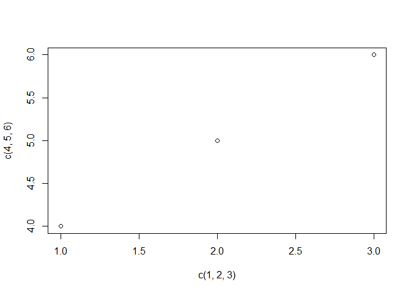

```r
plot(c(1, 2, 3), c(4, 5, 6))
```

51. Create XY-scatter of `iris` Sepal Length against Petal With.

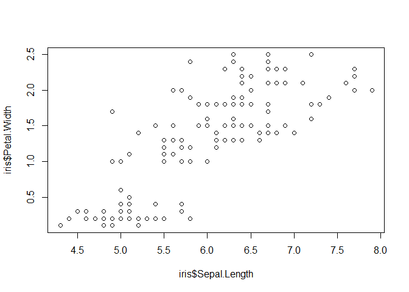

```r
plot(iris$Sepal.Length, iris$Petal.Width)
```

52. Again but with title and axis labels. Use whatever text you like.Blue dots.

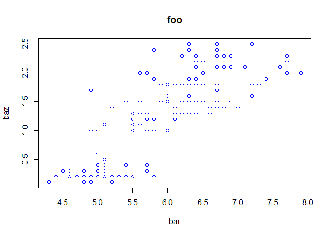

```r
plot(iris$Sepal.Length, iris$Petal.Width, main = "foo", xlab = "bar", ylab = "baz", col = "blue")
```

53. Create histogram of `iris` Sepal Lenght.

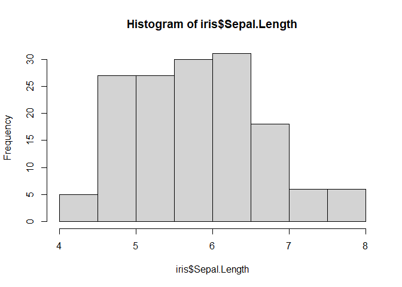

```r
hist(iris$Sepal.Length)
```

54. Again but with breaks of 0.25

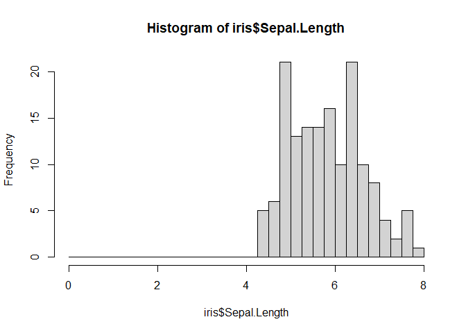

```r
brk <- seq(from = 0, to = 8, by = 0.25)
hist(iris$Sepal.Length, breaks = brk)
```

55. Create boxplot of `iris` Sepal Length and `iris` Sepal Width. Give labels (names) “sepal length” and “sepal width”.

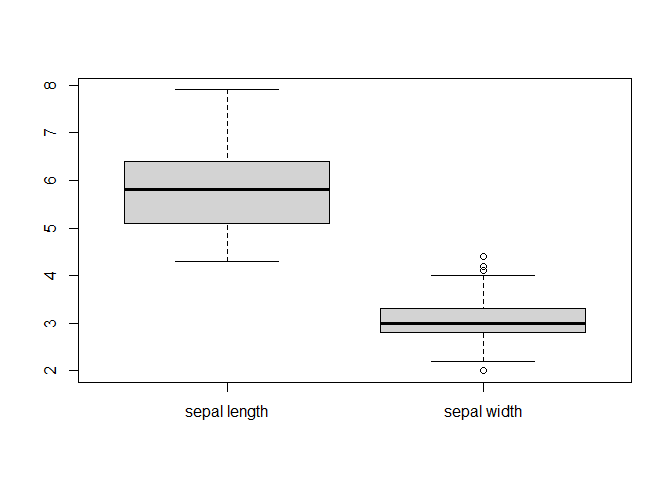

```r
boxplot(iris$Sepal.Length, iris$Sepal.Width, names = c("sepal length", "sepal width"))
```

```r
?boxplot
```

56. Create XY-scatter with y = c(1, 2, 3) and x = c(4, 5, 6) using the formula notation.

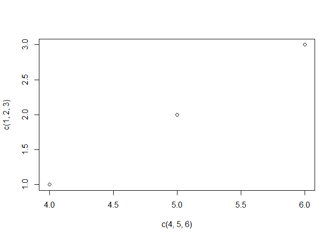

```r
plot(c(1, 2, 3) ~ c(4, 5, 6))
```

57. Create a barplot of vector c(1, 2, 3).

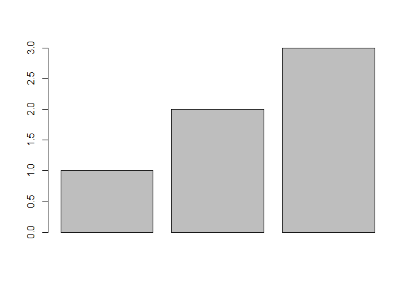

```r
barplot(c(1, 2, 3))
```

58. Create a barplot of vector c(1, 2, 3). Labels (names) = a, b, c.

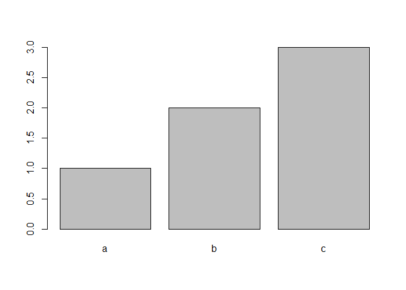

```r
barplot(c(1, 2, 3), names = c("a", "b", "c"))
```

59. Print the build in data frame `ChickWeight`.

```r
ChickWeight
```

```
##     weight Time Chick Diet
## 1       42    0     1    1
## 2       51    2     1    1
## 3       59    4     1    1
## 4       64    6     1    1
## 5       76    8     1    1
## 6       93   10     1    1
## 7      106   12     1    1
## 8      125   14     1    1
## 9      149   16     1    1
## 10     171   18     1    1
## 11     199   20     1    1
## 12     205   21     1    1
## 13      40    0     2    1
## 14      49    2     2    1
```

[output cut: 564 more lines]

60. Create XY-scatter of weight plotted against Time from data frame ChickWeight. Use formula notation.

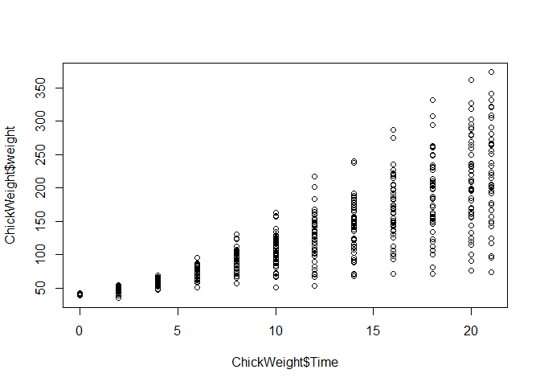

```r
plot(ChickWeight$weight ~ ChickWeight$Time)
```

61. Create a linair regression model. Print model to screen.

```r
my_formula <- lm(ChickWeight$weight ~ ChickWeight$Time)
my_formula
```

```
##
## Call:
## lm(formula = ChickWeight$weight ~ ChickWeight$Time)
##
## Coefficients:
##      (Intercept)  ChickWeight$Time
##           27.467             8.803
```

62. Create XY-scatter of weight plotted against Time from data frame ChickWeight. Use formula notation. Display the regression line.

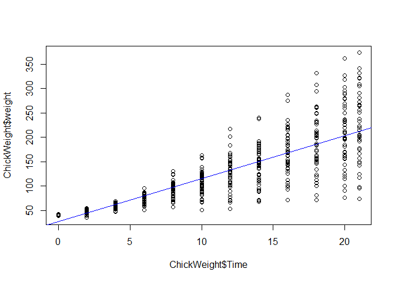

```r
plot(ChickWeight$weight ~ ChickWeight$Time)
abline(my_formula, col = "blue")
```

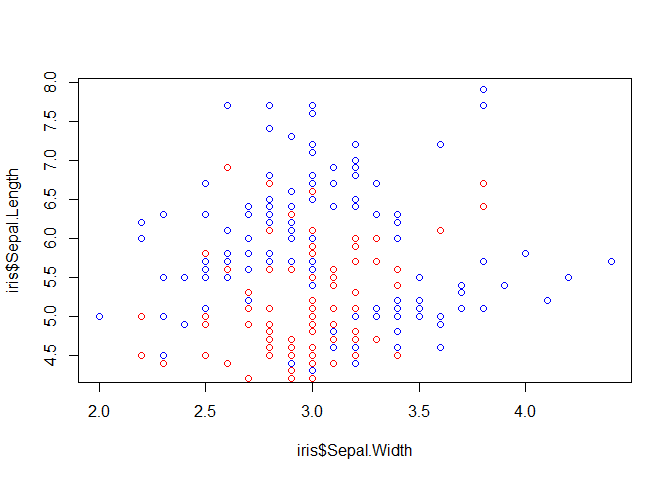

```r
plot(iris$Sepal.Length ~ iris$Sepal.Width, col="blue")
points(iris$Petal.Length ~ iris$Sepal.Width, col="red")
```

64. Create a line plot of x = c(1, 2, 3) and y = c(4, 5, 6) in blue.Add second series x = c(1, 2, 3) and y = c(5, 5.5, 6) in red.

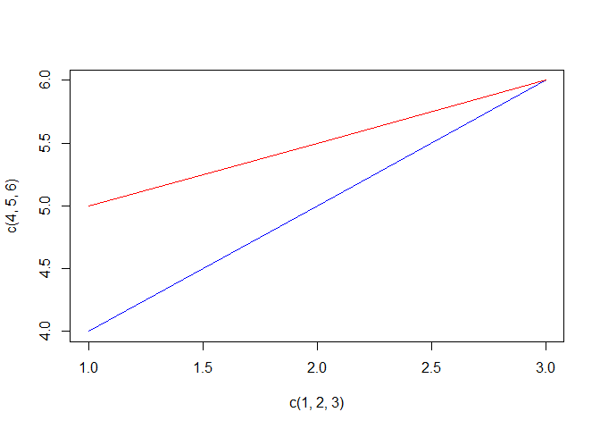

```r
plot(c(1, 2, 3), c(4, 5, 6), type="l", col="blue")
lines(c(1, 2, 3), c(5, 5.5, 6), col="red")
```

The end…

Go back to the main page  
Go back to the R overview page  
⬆️ Back to Top

> This web page is distributed under the terms of the Creative Commons Attribution License which permits unrestricted use, distribution, and reproduction in any medium, provided the original author and source are credited. Creative Commons License: CC BY-SA 4.0.